# Figure (Deviation) — BRCA + SCAN-B age-matched deviation

Pan-cancer aging project

July 18, 2026

```r
suppressPackageStartupMessages({
  library(dplyr)
  library(tibble)
  library(tidyr)
  library(readr)
  library(ggplot2)
  library(grid)        # unit()
  library(here)

  library(glmnet)      # for predict() on the saved enet model

  library(ClockSHAP)
  library(ComplexHeatmap)
  library(circlize)    # colorRamp2
})
```

# 1 — Load TCGA-BRCA pipeline outputs

```r
tcga_project <- params$tcga_project
gtex_project <- params$gtex_project
feature_set  <- params$feature_set
base_dir     <- params$base_dir

analysis_id  <- paste0(tcga_project, "__", gtex_project)
analysis_dir <- file.path(here::here(base_dir), analysis_id)
suffix       <- paste0("-", feature_set)

clock_rds      <- file.path(analysis_dir, paste0("clock_and_RAA_objects", suffix, ".rds"))
clockshap_rds  <- file.path(analysis_dir, paste0("clockshap_objects",     suffix, ".rds"))
metadata_rds   <- file.path(analysis_dir, "sample_metadata.rds")
scores_gtex_rds <- file.path(analysis_dir, paste0("ssgsea_scores_gtex",  suffix, ".rds"))

stopifnot(
  file.exists(clock_rds),
  file.exists(clockshap_rds),
  file.exists(metadata_rds),
  file.exists(scores_gtex_rds)
)

clock_results    <- readRDS(clock_rds)
clockshap_bundle <- readRDS(clockshap_rds)
metadata         <- readRDS(metadata_rds)
scores_gtex      <- readRDS(scores_gtex_rds)

feat <- clock_results$feature_names
stopifnot(all(feat %in% rownames(scores_gtex)))

# ClockSHAP for TCGA-BRCA primary tumors (already computed + saved by Step 04)
cs_brca <- clockshap_bundle$pt
stopifnot(inherits(cs_brca, "clockshap"))

message("TCGA-BRCA features in clock: ", length(feat),
        " | PT samples: ", nrow(cs_brca$phi))
```

# 2 — Fit GTEx reference line (shared anchoring)

We need the GTEx-only fit `pred ~ age` once; both Panel A and the SCAN-B anchored predictions reuse it.

```r
pred_gtex <- clock_results$pred$GTEx
age_gtex  <- clock_results$age$GTEx[names(pred_gtex)]

ok_g       <- complete.cases(pred_gtex, age_gtex)
pred_gtex  <- pred_gtex[ok_g]
age_gtex   <- age_gtex[ok_g]
bias_fit <- lm(pred_gtex ~ age_gtex)
beta0    <- coef(bias_fit)[1]
beta1    <- coef(bias_fit)[2]

c(beta0 = unname(beta0), beta1 = unname(beta1), n_gtex = length(pred_gtex))
```

```
##       beta0       beta1      n_gtex
##  42.6275560   0.1781736 482.0000000
```

```r
# ============================================================================
#   Sanity check — deviation consistency
#   For each cs object we have at this point, verify
#       cs$expected  == beta0 + beta1 * cs$age
#       cs$deviation == cs$predicted - (beta0 + beta1 * cs$age)
#   i.e. ClockSHAP's notion of "expected" is the same GTEx line we just fit.
# ============================================================================
check_dev_vs_gtex_line <- function(cs, label, beta0, beta1, tol = 1e-6) {
  stopifnot(all(c("age", "predicted", "expected", "deviation") %in% names(cs)))

  exp_recon <- beta0 + beta1 * cs$age
  dev_recon <- cs$predicted - exp_recon

  d_exp <- max(abs(cs$expected  - exp_recon), na.rm = TRUE)
  d_dev <- max(abs(cs$deviation - dev_recon), na.rm = TRUE)

  message(sprintf(
    "[%-18s] max |expected - GTEx line| = %.3g | max |deviation - (pred - GTEx line)| = %.3g",
    label, d_exp, d_dev
  ))
  invisible(c(d_exp = d_exp, d_dev = d_dev))
}

# Primary tumor (the cs object Panels B/C/D actually read from)
chk_pt  <- check_dev_vs_gtex_line(cs_brca, "TCGA-BRCA PT", beta0, beta1)

# Adjacent normal, if present in the bundle (Panel B anchor)
chk_nat <- if (!is.null(clockshap_bundle$nat)) {
  check_dev_vs_gtex_line(clockshap_bundle$nat, "TCGA-BRCA NAT", beta0, beta1)
} else {
  message("clockshap_bundle$nat not present — skipping NAT check.")
  c(d_exp = NA_real_, d_dev = NA_real_)
}

stopifnot(chk_pt["d_dev"] < 1e-6)
if (!is.na(chk_nat["d_dev"])) stopifnot(chk_nat["d_dev"] < 1e-6)
```

# 3 — Load SCAN-B pre-processed inputs (ssGSEA + coldata)

The supp script `supp_SCANB_replication_BRCA_clock` already computed and saved the SCAN-B Hallmark ssGSEA matrix and the relevant coldata (sample_id, age_years, SSP.PAM50, RFi_days, RFi_event). We pick up from there.

```r
stopifnot(file.exists(params$scanb_inputs_rds))
scanb_inputs <- readRDS(params$scanb_inputs_rds)

stopifnot(
  is.list(scanb_inputs),
  all(c("ssgsea_scores", "coldata") %in% names(scanb_inputs))
)

scanb_scores_pxs <- scanb_inputs$ssgsea_scores   # pathways x samples
scanb_coldata    <- scanb_inputs$coldata         # data.frame, rownames = sample IDs

stopifnot(all(feat %in% rownames(scanb_scores_pxs)))

message("SCAN-B samples loaded: ", ncol(scanb_scores_pxs))
```

# 4 — Apply BRCA clock to SCAN-B (raw + GTEx-anchored predictions)

```r
X_scanb     <- t(scanb_scores_pxs[feat, , drop = FALSE])
scanb_ids   <- rownames(X_scanb)
scanb_age   <- as.numeric(scanb_coldata[scanb_ids, "age_years"])
names(scanb_age) <- scanb_ids

pred_scanb_raw <- as.numeric(predict(
  clock_results$enet_model,
  newx = X_scanb,
  s    = clock_results$tuning$best_lambda
))
names(pred_scanb_raw) <- scanb_ids

scanb_pred_df <- tibble(
  sample_id = scanb_ids,
  age_years = scanb_age[scanb_ids],
  predicted = pred_scanb_raw[scanb_ids]
) %>%
  filter(is.finite(age_years), is.finite(predicted)) %>%
  mutate(
    pred_anchored = predicted - beta0 + (1 - beta1) * age_years,
    dev_gtex      = predicted - (beta0 + beta1 * age_years)
  )
```

# 5 — ClockSHAP on SCAN-B (using the saved BRCA reference + clock)

```r
clock_cs  <- clockshap_bundle$clock
reference <- clockshap_bundle$reference

ok_scanb     <- is.finite(scanb_pred_df$age_years) & scanb_pred_df$age_years > 0
X_scanb_cs   <- X_scanb[scanb_pred_df$sample_id[ok_scanb], , drop = FALSE]
age_scanb_cs <- scanb_pred_df$age_years[ok_scanb]

cs_scanb <- ClockSHAP::clockshap(
  features  = X_scanb_cs,
  age       = age_scanb_cs,
  clock     = clock_cs,
  reference = reference
)

# Invariant: rowSums(phi) == deviation
inv_max <- max(abs(rowSums(cs_scanb$phi) - cs_scanb$deviation))
message("SCAN-B ClockSHAP invariant max |rowSums(phi) - deviation| = ",
        signif(inv_max, 3))
stopifnot(inv_max < 1e-8)

chk_scanb <- check_dev_vs_gtex_line(cs_scanb, "SCAN-B PT", beta0, beta1)
stopifnot(chk_scanb["d_dev"] < 1e-6)
```

# 6 — Attach TP53 status to SCAN-B (Brueffer 2020 export)

Same deleterious-variant filter as the TCGA pipeline, mapped onto Brueffer’s coarser SnpEff effect classes. Samples *outside* the Brueffer 2020 cohort of 3,217 are left as `NA` (we cannot confidently call WT for them).

```r
scanb_tp53_tsv <- params$scanb_tp53_tsv

if (file.exists(scanb_tp53_tsv)) {

  mut <- readr::read_tsv(
    scanb_tp53_tsv,
    comment        = "##",
    show_col_types = FALSE
  )

  req_cols <- c("SAMPLE", "gene.symbol", "SnpEff.Effect.Class")
  if (!all(req_cols %in% colnames(mut))) {
    warning("SCAN-B mutation TSV missing required columns (need: ",
            paste(req_cols, collapse = ", "),
            "); skipping TP53 attach.")
  } else {

    keep_classes <- c("Missense", "Nonsense", "Frameshift", "Splicing", "In-frame indel")

    tp53_mut_samples <- mut |>
      dplyr::filter(
        gene.symbol == "TP53",
        SnpEff.Effect.Class %in% keep_classes
      ) |>
      dplyr::pull(SAMPLE) |>
      unique()

    cohort_ids <- unique(mut$SAMPLE)

    scanb_ids_full  <- rownames(scanb_coldata)
    scanb_ids_match <- sub("\\.k2\\.a\\.t$", "", scanb_ids_full)

    tp53_vec        <- rep(NA_character_, length(scanb_ids_full))
    names(tp53_vec) <- scanb_ids_full

    in_cohort <- scanb_ids_match %in% cohort_ids
    tp53_vec[in_cohort] <- ifelse(
      scanb_ids_match[in_cohort] %in% tp53_mut_samples, "Mut", "WT"
    )

    scanb_coldata$TP53 <- tp53_vec

    message(
      "SCAN-B TP53 attach: ",
      "Mut=",   sum(tp53_vec == "Mut", na.rm = TRUE),
      " | WT=", sum(tp53_vec == "WT",  na.rm = TRUE),
      " | NA=", sum(is.na(tp53_vec)),
      " (NA = outside Brueffer 2020 cohort of 3,217)"
    )
  }

} else {
  message("SCAN-B TP53 attach skipped (file not found): ", scanb_tp53_tsv)
}
```

```r
out_dir <- here::here(params$fig_dir)
if (isTRUE(params$save_figures)) {
  dir.create(out_dir, recursive = TRUE, showWarnings = FALSE)
}
```

# Panel A — Anchored predicted age vs chronological age (4 cohorts)

GTEx, TCGA-BRCA NAT, TCGA-BRCA primary tumors, and SCAN-B primary tumors plotted on the same anchored-age axis (`pred - beta0 + (1 - beta1) * age`). GTEx is anchored to identity by construction; the vertical displacement of each tumor cohort from identity is the GTEx-anchored deviation.

```r
# GTEx
gtex_df <- tibble(
  cohort        = "GTEx",
  age_years     = as.numeric(age_gtex),
  pred_anchored = as.numeric(pred_gtex - beta0 + (1 - beta1) * age_gtex)
) %>%
  filter(complete.cases(age_years, pred_anchored))

# TCGA-NAT
pred_nat <- clock_results$pred$NAT
age_nat  <- clock_results$age$NAT[names(pred_nat)]
ok_n     <- complete.cases(pred_nat, age_nat)
pred_nat <- pred_nat[ok_n]
age_nat  <- age_nat[ok_n]

nat_df <- tibble(
  cohort        = "TCGA-NAT",
  age_years     = as.numeric(age_nat),
  pred_anchored = as.numeric(pred_nat - beta0 + (1 - beta1) * age_nat)
) %>%
  filter(complete.cases(age_years, pred_anchored))

# TCGA-BRCA primary tumors
pred_pt_full <- clock_results$pred$Tumour
age_pt_full  <- clock_results$age$Tumour[names(pred_pt_full)]
ok_t         <- complete.cases(pred_pt_full, age_pt_full)
pred_pt_full <- pred_pt_full[ok_t]
age_pt_full  <- age_pt_full[ok_t]

pt_df <- tibble(
  cohort        = "TCGA-PT",
  age_years     = as.numeric(age_pt_full),
  pred_anchored = as.numeric(pred_pt_full - beta0 + (1 - beta1) * age_pt_full)
) %>%
  filter(complete.cases(age_years, pred_anchored))

# SCAN-B
scanb_df <- scanb_pred_df %>%
  transmute(
    cohort        = "SCAN-B",
    age_years,
    pred_anchored
  )

panelA_df <- bind_rows(gtex_df, nat_df, pt_df, scanb_df) %>%
  mutate(cohort = factor(cohort, levels = c("GTEx", "TCGA-NAT", "TCGA-PT", "SCAN-B")))

table(panelA_df$cohort)
```

```
##
##     GTEx TCGA-NAT  TCGA-PT   SCAN-B
##      482      112     1117     7744
```

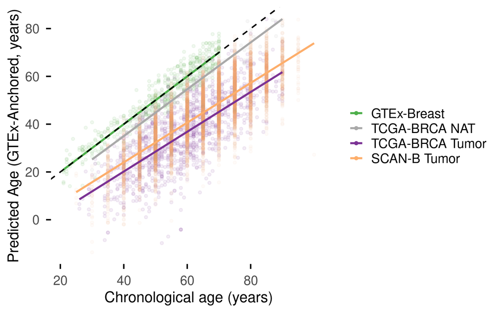

```r
panelA_cols <- c(
  "GTEx"     = "#4daf4a",   # green (kept — matches Fig 3A + Supp 3A)
  "TCGA-NAT" = "darkgray",   # dark grey (matches Panel E "Pooled")
  "TCGA-PT"  = "#7b3294",   # purple (matches Panel E + OS figure)
  "SCAN-B"   = "#fdae6b"    # orange (matches Supp 3A)
)

panelA_labels <- c(
  "GTEx"     = "GTEx-Breast",
  "TCGA-NAT" = "TCGA-BRCA NAT",
  "TCGA-PT"  = "TCGA-BRCA Tumor",
  "SCAN-B"   = "SCAN-B Tumor"
)

common_breaks <- c(0, 20, 40, 60, 80)

p_panelA <- ggplot(panelA_df, aes(x = age_years, y = pred_anchored, colour = cohort)) +
  geom_point(aes(alpha = cohort), size = 1.2) +
  geom_smooth(method = "lm", se = FALSE, linewidth = 1.1) +
  geom_abline(slope = 1, intercept = 0, linetype = "dashed", colour = "black") +
  scale_colour_manual(values = panelA_cols, labels = panelA_labels) +
  scale_alpha_manual(
    values = c("GTEx" = 0.08, "TCGA-NAT" = 0.08, "TCGA-PT" = 0.08, "SCAN-B" = 0.04),
    guide  = "none"
  ) +
  scale_x_continuous(breaks = common_breaks) +
  scale_y_continuous(breaks = common_breaks) +
  labs(
    x = "Chronological age (years)",
    y = "Predicted Age (GTEx-Anchored, years)"
  ) +
  theme_minimal(base_size = 17) +
  theme(
    legend.title      = element_blank(),
    panel.grid.minor  = element_blank(),
    panel.grid.major  = element_blank(),
    axis.ticks        = element_line(),
    axis.ticks.length = unit(2, "mm"),
    axis.title        = element_text(size = 17),
    axis.text         = element_text(size = 15),
    legend.text       = element_text(size = 15)
  )

p_panelA
```

```r
if (isTRUE(params$save_figures)) {
  ggsave(
    filename = file.path(out_dir, "PanelA_anchored_age_4cohorts.pdf"),
    plot     = p_panelA,
    width    = 220 / 25.4,
    height   = 130 / 25.4,
    units    = "in"
  )
  message("Saved: ", file.path(out_dir, "PanelA_anchored_age_4cohorts.pdf"))
}
```

# Panel B — Age-matched deviation by cohort

```r
# Cohort-level age-matched deviations (same GTEx anchoring as Panel A)
dev_gtex_b  <- as.numeric(pred_gtex - (beta0 + beta1 * age_gtex))
dev_nat_b   <- if (!is.null(clockshap_bundle$nat)) {
  as.numeric(clockshap_bundle$nat$deviation)
} else {
  numeric(0)
}
dev_pt_b    <- as.numeric(cs_brca$deviation)
dev_scanb_b <- as.numeric(cs_scanb$deviation)

panelB_df <- bind_rows(
  tibble(cohort = "GTEx",     deviation = dev_gtex_b),
  tibble(cohort = "TCGA-NAT", deviation = dev_nat_b),
  tibble(cohort = "TCGA-PT",  deviation = dev_pt_b),
  tibble(cohort = "SCAN-B",   deviation = dev_scanb_b)
) %>%
  filter(is.finite(deviation)) %>%
  mutate(
    cohort = factor(cohort, levels = c("GTEx", "TCGA-NAT", "TCGA-PT", "SCAN-B")),
    tissue = "Breast"   # single facet level -> Panel-D-style left strip
  )

table(panelB_df$cohort)
```

```
##
##     GTEx TCGA-NAT  TCGA-PT   SCAN-B
##      482      112     1117     7744
```

```r
# Shared p-value formatter (also used by Panel D)
fmt_p <- function(p) {
  if (!is.finite(p)) return("p = NA")
  if (p < 2.2e-16)   return("p < 2.2e-16")
  paste0("p = ", formatC(p, format = "e", digits = 2))
}

panelB_kw      <- suppressWarnings(
  kruskal.test(deviation ~ droplevels(cohort), data = panelB_df)$p.value
)
panelB_p_label <- paste0("Kruskal–Wallis ", fmt_p(panelB_kw))
panelB_p_label
```

```
## [1] "Kruskal–Wallis p < 2.2e-16"
```

```r
panelB_labels <- c(
  "GTEx"     = "GTEx-Breast",
  "TCGA-NAT" = "Adjacent Normal",
  "TCGA-PT"  = "TCGA-BRCA",
  "SCAN-B"   = "SCAN-B"
)

# p-value label at top-left of the panel (same convention as Panel D)
y_max_b   <- max(panelB_df$deviation, na.rm = TRUE)
y_min_b   <- min(panelB_df$deviation, na.rm = TRUE)
y_label_b <- y_max_b + 0.05 * (y_max_b - y_min_b)

panelB_pval_df <- tibble(
  tissue    = "Breast",
  deviation = y_label_b,
  p_label   = panelB_p_label
)

panelB_summary <- panelB_df %>%
  group_by(cohort) %>%
  summarise(
    n      = n(),
    mean   = round(mean(deviation), 2),
    median = round(median(deviation), 2),
    .groups = "drop"
  )

print(panelB_summary)
```

```
## # A tibble: 4 × 4
##   cohort       n   mean median
##   <fct>    <int>  <dbl>  <dbl>
## 1 GTEx       482   0     -0.09
## 2 TCGA-NAT   112  -5.33  -5.03
## 3 TCGA-PT   1117 -22.9  -23.1
## 4 SCAN-B    7744 -20.2  -19.6
```

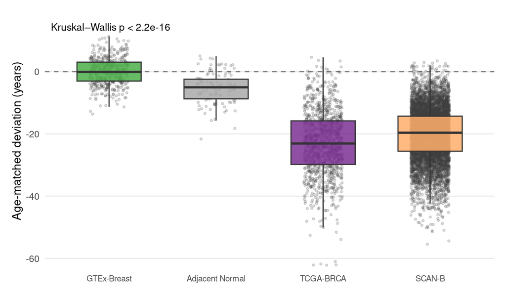

```r
p_panelB <- ggplot(panelB_df, aes(x = cohort, y = deviation, fill = cohort)) +
  geom_hline(yintercept = 0, linetype = "dashed", colour = "grey50") +
  geom_jitter(width = 0.18, alpha = 0.18, size = 0.7, colour = "grey25") +
  geom_boxplot(width = 0.6, outlier.shape = NA, alpha = 0.85) +
  scale_fill_manual(values = panelA_cols, guide = "none") +
  scale_x_discrete(labels = panelB_labels) +
  facet_grid(
    rows   = vars(tissue),
    switch = "y"
  ) +
  coord_cartesian(ylim = c(-60, NA)) +
  geom_text(
    data        = panelB_pval_df,
    aes(x = -Inf, y = deviation, label = p_label),
    hjust       = -0.05,
    vjust       = 1,
    size        = 3,
    inherit.aes = FALSE
  ) +
  labs(
    x = NULL,
    y = "Age-matched deviation (years)"
  ) +
  theme_minimal(base_size = 10) +
  theme(
    panel.grid.minor   = element_blank(),
    panel.grid.major.x = element_blank(),
    axis.title.y       = element_text(size = 10),
    axis.text.x        = element_text(size = 7),
    axis.text.y        = element_text(size = 8),
    strip.text.y       = element_blank(),
    strip.background   = element_blank(),
    plot.margin        = margin(10, 10, 10, 10)
  )

p_panelB
```

```r
if (isTRUE(params$save_figures)) {
  ggsave(
    filename = file.path(out_dir, "PanelB_DevByCohort.pdf"),
    plot     = p_panelB,
    width    = 4,
    height   = 2.75,
    units    = "in"
  )
  message("Saved: ", file.path(out_dir, "PanelB_DevByCohort.pdf"))
}
```

# Panel C — ClockSHAP heatmaps (TCGA-BRCA + SCAN-B, shared scales)

Per-pathway ClockSHAP contributions across tumors, ordered within each cohort by total age-matched deviation. Two heatmaps with **shared color scales, shared annotation palettes, and a single set of legends + row labels** that live on the TCGA-BRCA side. SCAN-B inherits BRCA’s pathway row order from hierarchical clustering, so rows align across cohorts and the TCGA row labels visually carry over during manual figure assembly.

## C.1 — Build matrices, row clustering, and shared color scales

```r
# ============================================================================
#   TCGA-BRCA matrix
# ============================================================================
phi_brca_full <- cs_brca$phi
dev_brca_full <- cs_brca$deviation
ids_brca_full <- rownames(phi_brca_full)

ok_b <- is.finite(dev_brca_full)
phi_brca_ok <- phi_brca_full[ok_b, , drop = FALSE]
dev_brca_ok <- dev_brca_full[ok_b]
ids_brca_ok <- ids_brca_full[ok_b]

ord_b <- order(dev_brca_ok, decreasing = FALSE)
phi_brca_ord <- phi_brca_ok[ord_b, , drop = FALSE]
dev_ord_brca <- dev_brca_ok[ord_b]
ids_ord_brca <- ids_brca_ok[ord_b]

mat_brca <- t(phi_brca_ord)
colnames(mat_brca) <- ids_ord_brca
mat_brca <- mat_brca[rowSums(abs(mat_brca), na.rm = TRUE) != 0, , drop = FALSE]
rownames(mat_brca)[rownames(mat_brca) == "Reactive Oxygen Species Pathway"] <- "ROS Pathway"

# Cluster on BRCA -- SCAN-B will inherit this ordering
hc_brca <- hclust(dist(mat_brca))
brca_row_order <- rownames(mat_brca)[hc_brca$order]

# ============================================================================
#   SCAN-B matrix (rows reordered to match BRCA)
# ============================================================================
phi_scanb_full <- cs_scanb$phi
dev_scanb_full <- cs_scanb$deviation
ids_scanb_full <- rownames(phi_scanb_full)

ok_s <- is.finite(dev_scanb_full)
phi_scanb_ok <- phi_scanb_full[ok_s, , drop = FALSE]
dev_scanb_ok <- dev_scanb_full[ok_s]
ids_scanb_ok <- ids_scanb_full[ok_s]

ord_s <- order(dev_scanb_ok, decreasing = FALSE)
phi_scanb_ord <- phi_scanb_ok[ord_s, , drop = FALSE]
dev_ord_scanb <- dev_scanb_ok[ord_s]
ids_ord_scanb <- ids_scanb_ok[ord_s]

mat_scanb <- t(phi_scanb_ord)
colnames(mat_scanb) <- ids_ord_scanb
mat_scanb <- mat_scanb[rowSums(abs(mat_scanb), na.rm = TRUE) != 0, , drop = FALSE]
rownames(mat_scanb)[rownames(mat_scanb) == "Reactive Oxygen Species Pathway"] <- "ROS Pathway"

# Inherit BRCA row order; intersect drops any pathway absent from SCAN-B
common_rows <- intersect(brca_row_order, rownames(mat_scanb))
n_dropped   <- length(setdiff(rownames(mat_scanb), common_rows))
n_added     <- length(setdiff(brca_row_order, common_rows))
mat_scanb   <- mat_scanb[common_rows, , drop = FALSE]
message(
  "Panel C row alignment: ", length(common_rows), " pathways shared | ",
  n_dropped, " in SCAN-B but not in BRCA (dropped) | ",
  n_added,   " in BRCA but not in SCAN-B (skipped)."
)

# ============================================================================
#   Shared color scales (computed across BOTH cohorts)
# ============================================================================
# Deviation: across-cohort min / 0 / max
dev_col_fun <- circlize::colorRamp2(
  c(min(c(dev_ord_brca, dev_ord_scanb), na.rm = TRUE),
    0,
    max(c(dev_ord_brca, dev_ord_scanb), na.rm = TRUE)),
  c("darkblue", "white", "darkred")
)

# Phi: 99th percentile of |phi| across both matrices, symmetric ramp
phi_lim <- as.numeric(stats::quantile(
  c(abs(mat_brca), abs(mat_scanb)),
  probs = 0.99, na.rm = TRUE
))
phi_lim <- max(phi_lim, 1e-6)

phi_col_fun <- circlize::colorRamp2(
  c(-phi_lim, 0, phi_lim),
  c("steelblue", "white", "firebrick")
)

# ============================================================================
#   Shared annotation palettes (superset across cohorts so legend covers both)
# ============================================================================
pam_cols_shared <- c(
  Basal         = "#d73027",
  Her2          = "#fc8d59",
  LumA          = "#4575b4",
  LumB          = "#91bfdb",
  `Normal-Like` = "#cccccc",
  Unclassified  = "grey70"      # SCAN-B only; absent in TCGA but in legend
)
tp53_cols_shared <- c(WT = "grey85", Mut = "black", Unknown = "white")

pam_levels_full  <- names(pam_cols_shared)
tp53_levels_full <- names(tp53_cols_shared)

# ---- TCGA-BRCA annotation vectors as factors with full level set ----
pam_brca <- as.character(metadata[ids_ord_brca, "Subtype_Selected"])
pam_brca <- dplyr::recode(pam_brca, "Normal" = "Normal-Like")
pam_brca <- factor(pam_brca, levels = pam_levels_full)

tp53_brca <- as.character(metadata[ids_ord_brca, "TP53"])
tp53_brca[is.na(tp53_brca) | tp53_brca == ""] <- "Unknown"
tp53_brca <- factor(tp53_brca, levels = tp53_levels_full)

# ---- SCAN-B annotation vectors as factors with full level set ----
pam_scanb <- as.character(scanb_coldata[ids_ord_scanb, "SSP.PAM50"])
pam_scanb[is.na(pam_scanb) | pam_scanb == ""] <- "Unclassified"
pam_scanb <- dplyr::recode(pam_scanb, "Normal" = "Normal-Like")
pam_scanb <- factor(pam_scanb, levels = pam_levels_full)

tp53_scanb <- if ("TP53" %in% colnames(scanb_coldata)) {
  as.character(scanb_coldata[ids_ord_scanb, "TP53"])
} else {
  rep(NA_character_, length(ids_ord_scanb))
}
tp53_scanb[is.na(tp53_scanb) | tp53_scanb == ""] <- "Unknown"
tp53_scanb <- factor(tp53_scanb, levels = tp53_levels_full)
```

## C.2 — TCGA-BRCA heatmap (legends + row labels live here)

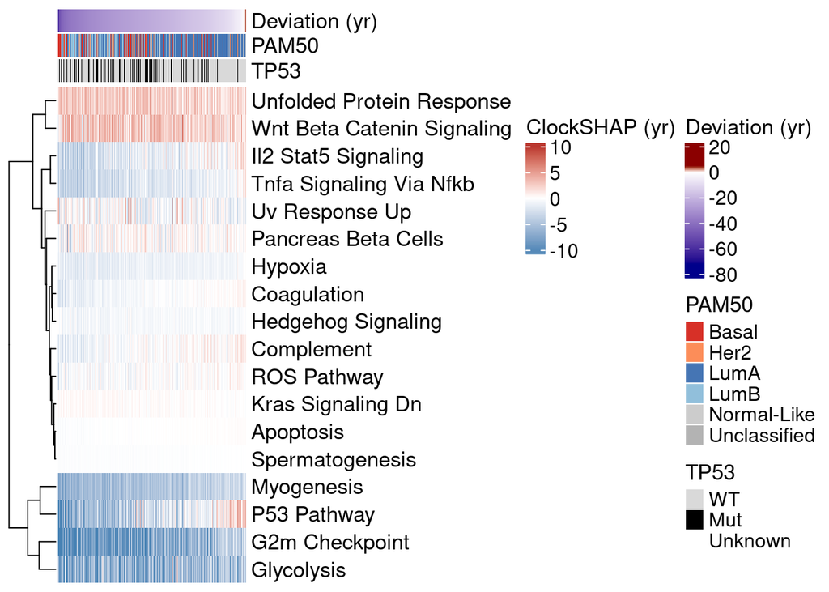

```r
ha_brca <- ComplexHeatmap::HeatmapAnnotation(
  Deviation = dev_ord_brca,
  PAM50     = pam_brca,
  TP53      = tp53_brca,
  col = list(
    Deviation = dev_col_fun,
    PAM50     = pam_cols_shared,
    TP53      = tp53_cols_shared
  ),
  annotation_label = list(
    Deviation = "Deviation (yr)",
    PAM50     = "PAM50",
    TP53      = "TP53"
  ),
  annotation_height  = unit(c(3, 3, 3), "mm"),
  annotation_name_gp = gpar(fontsize = 13),
  annotation_legend_param = list(
    Deviation = list(
      title_gp  = gpar(fontsize = 13),
      labels_gp = gpar(fontsize = 12)
    ),
    PAM50 = list(
      title_gp  = gpar(fontsize = 13),
      labels_gp = gpar(fontsize = 12),
      at        = pam_levels_full,   # force ALL levels in legend (incl. Unclassified)
      labels    = pam_levels_full
    ),
    TP53 = list(
      title_gp  = gpar(fontsize = 13),
      labels_gp = gpar(fontsize = 12),
      at        = tp53_levels_full,
      labels    = tp53_levels_full
    )
  )
)

ht_panelC_brca <- ComplexHeatmap::Heatmap(
  mat_brca,
  name              = "ClockSHAP (yr)",
  col               = phi_col_fun,
  top_annotation    = ha_brca,
  show_row_names    = TRUE,
  row_names_gp      = gpar(fontsize = 13),
  show_column_names = FALSE,
  cluster_rows      = hc_brca,
  cluster_columns   = FALSE,
  show_heatmap_legend  = TRUE,
  heatmap_legend_param = list(
    title_gp  = gpar(fontsize = 13),
    labels_gp = gpar(fontsize = 12)
  )
)

ht_panelC_brca
```

```r
if (isTRUE(params$save_figures)) {
  out_file <- file.path(out_dir, "PanelC_BRCA_ClockSHAP_heatmap.pdf")

  grDevices::pdf(out_file, width = 190 / 25.4, height = 160 / 25.4)
  ComplexHeatmap::draw(
    ht_panelC_brca,
    heatmap_legend_side    = "right",
    annotation_legend_side = "right",
    merge_legends          = TRUE
  )
  grDevices::dev.off()

  message("Saved: ", out_file)
}
```

## C.3 — SCAN-B heatmap (no row labels, no legends — relies on TCGA’s)

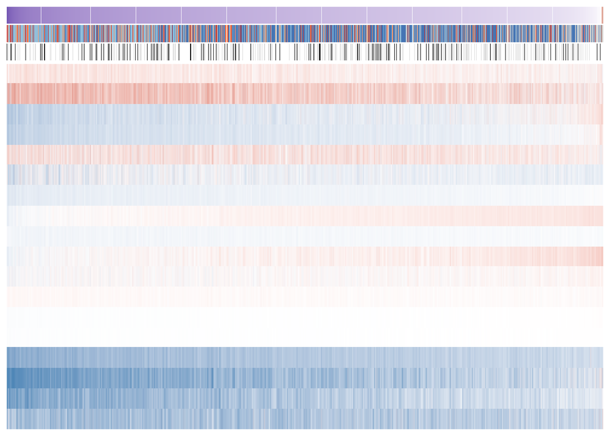

```r
ha_scanb <- ComplexHeatmap::HeatmapAnnotation(
  Deviation = dev_ord_scanb,
  PAM50     = pam_scanb,
  TP53      = tp53_scanb,
  col = list(
    Deviation = dev_col_fun,
    PAM50     = pam_cols_shared,
    TP53      = tp53_cols_shared
  ),
  annotation_height    = unit(c(3, 3, 3), "mm"),
  show_annotation_name = FALSE,                             # strip names live on BRCA
  show_legend          = c(Deviation = FALSE,
                           PAM50     = FALSE,
                           TP53      = FALSE)
)

ht_panelC_scanb <- ComplexHeatmap::Heatmap(
  mat_scanb,
  name                = "ClockSHAP (yr)",                   # same name as BRCA -> consistent
  col                 = phi_col_fun,
  top_annotation      = ha_scanb,
  show_row_names      = FALSE,
  show_column_names   = FALSE,
  cluster_rows        = FALSE,                              # row order baked in via mat_scanb
  cluster_columns     = FALSE,
  show_heatmap_legend = FALSE
)

ht_panelC_scanb
```

```r
if (isTRUE(params$save_figures)) {
  out_file <- file.path(out_dir, "PanelC_SCANB_ClockSHAP_heatmap.pdf")

  # Narrower than BRCA: no row labels (~50mm saved), no legends (~40mm saved).
  # ~110mm = enough for the strips + heatmap body; adjust in Illustrator.
  grDevices::pdf(out_file, width = 110 / 25.4, height = 160 / 25.4)
  ComplexHeatmap::draw(
    ht_panelC_scanb,
    heatmap_legend_side    = "right",
    annotation_legend_side = "right"
  )
  grDevices::dev.off()

  message("Saved: ", out_file)
}
```

```r
summarise_phi <- function(mat, cohort_label) {
  tibble::tibble(
    cohort  = cohort_label,
    pathway = rownames(mat),
    n       = ncol(mat),
    min     = round(apply(mat, 1, min,    na.rm = TRUE), 3),
    max     = round(apply(mat, 1, max,    na.rm = TRUE), 3),
    mean    = round(apply(mat, 1, mean,   na.rm = TRUE), 3),
    median  = round(apply(mat, 1, median, na.rm = TRUE), 3)
  )
}

panelC_pathway_summary <- bind_rows(
  summarise_phi(mat_brca,  "TCGA-BRCA"),
  summarise_phi(mat_scanb, "SCAN-B")
)

print(panelC_pathway_summary, n = Inf)
```

```
## # A tibble: 36 × 7
##    cohort    pathway                        n     min    max   mean median
##    <chr>     <chr>                      <int>   <dbl>  <dbl>  <dbl>  <dbl>
##  1 TCGA-BRCA Apoptosis                   1117  -0.46   0.315 -0.014 -0.005
##  2 TCGA-BRCA Coagulation                 1117  -3.69   1.28  -0.462 -0.373
##  3 TCGA-BRCA Complement                  1117  -3.44   3.01  -0.229 -0.241
##  4 TCGA-BRCA G2m Checkpoint              1117 -16.0   -0.074 -7.42  -7.20
##  5 TCGA-BRCA Glycolysis                  1117 -17.5    5.43  -6.31  -6.11
##  6 TCGA-BRCA Hedgehog Signaling          1117  -1.88   0.848 -0.518 -0.493
##  7 TCGA-BRCA Hypoxia                     1117  -3.02   0.712 -1.13  -1.10
##  8 TCGA-BRCA Il2 Stat5 Signaling         1117  -6.71   4.68  -1.44  -1.49
##  9 TCGA-BRCA Kras Signaling Dn           1117  -1.16   0.932  0.145  0.152
## 10 TCGA-BRCA Myogenesis                  1117  -9.46   5.22  -4.77  -4.80
## 11 TCGA-BRCA P53 Pathway                 1117 -21.7   10.2   -2.96  -2.74
## 12 TCGA-BRCA Pancreas Beta Cells         1117 -11.2    4.82   0.069  0.206
```

[output cut: 24 more lines]

# Panel D — PAM50 deviation by cohort

Statistical anchor for the PAM50 annotation strip in Panel C. Two facets on a shared deviation y-axis: TCGA-BRCA (with Adjacent Normal as leftmost reference) and SCAN-B. PAM50 ordering is fixed left-to-right by canonical aggressiveness convention (Normal-Like → LumA → LumB → Her2 → Basal). The Kruskal–Wallis omnibus tests whether tumor subtypes differ from each other (NAT excluded — tumors vs normal is visually obvious and not the question).

## D.1 — Build long-form data

```r
# ---- TCGA-BRCA: PAM50 by deviation ----
ids_brca   <- rownames(cs_brca$phi)
dev_brca_d <- cs_brca$deviation

pam50_brca <- as.character(metadata[ids_brca, "Subtype_Selected"])
pam50_brca[is.na(pam50_brca) | pam50_brca == ""] <- NA_character_
pam50_brca <- dplyr::recode(pam50_brca, "Normal" = "Normal-Like")

# ---- TCGA-BRCA Adjacent Normal (NAT): leftmost reference ----
# Pulled from the saved Step-04 ClockSHAP bundle. NAT is shown as anchor
# only -- it is NOT included in the KW omnibus across tumor subtypes.
dev_nat_d <- if (!is.null(clockshap_bundle$nat)) {
  as.numeric(clockshap_bundle$nat$deviation)
} else {
  numeric(0)
}
message("TCGA-BRCA NAT samples for Panel D anchor: ", length(dev_nat_d))

# ---- SCAN-B: PAM50 by deviation ----
ids_scanb   <- rownames(cs_scanb$phi)
dev_scanb_d <- cs_scanb$deviation

pam50_scanb <- as.character(scanb_coldata[ids_scanb, "SSP.PAM50"])
pam50_scanb[is.na(pam50_scanb) | pam50_scanb == ""] <- NA_character_
pam50_scanb <- dplyr::recode(pam50_scanb, "Normal" = "Normal-Like")

# ---- Long-form for ggplot ----
pam50_levels <- c("Adjacent Normal", "Normal-Like", "LumA", "LumB", "Her2", "Basal")

panelD_df <- bind_rows(
  # NAT (TCGA only, leftmost reference)
  if (length(dev_nat_d) > 0) {
    tibble(
      cohort    = "TCGA-BRCA",
      group     = "Adjacent Normal",
      deviation = dev_nat_d
    )
  } else {
    tibble(cohort = character(), group = character(), deviation = numeric())
  },
  tibble(
    cohort    = "TCGA-BRCA",
    group     = pam50_brca,
    deviation = as.numeric(dev_brca_d)
  ),
  tibble(
    cohort    = "SCAN-B",
    group     = pam50_scanb,
    deviation = as.numeric(dev_scanb_d)
  )
) %>%
  filter(group %in% pam50_levels, is.finite(deviation)) %>%
  mutate(
    cohort = factor(cohort, levels = c("TCGA-BRCA", "SCAN-B")),
    group  = factor(group, levels = pam50_levels)
  )

panelD_df %>%
  count(cohort, group) %>%
  arrange(cohort, group)
```

```
## # A tibble: 11 × 3
##    cohort    group               n
##    <fct>     <fct>           <int>
##  1 TCGA-BRCA Adjacent Normal   112
##  2 TCGA-BRCA Normal-Like        40
##  3 TCGA-BRCA LumA              573
##  4 TCGA-BRCA LumB              217
##  5 TCGA-BRCA Her2               81
##  6 TCGA-BRCA Basal             206
##  7 SCAN-B    Normal-Like      1023
##  8 SCAN-B    LumA             3254
##  9 SCAN-B    LumB             1903
## 10 SCAN-B    Her2              885
## 11 SCAN-B    Basal             679
```

```r
panelD_summary <- panelD_df %>%
  group_by(cohort, group) %>%
  summarise(
    n      = n(),
    mean   = round(mean(deviation), 2),
    median = round(median(deviation), 2),
    .groups = "drop"
  )

print(panelD_summary, n = Inf)
```

```
## # A tibble: 11 × 5
##    cohort    group               n   mean median
##    <fct>     <fct>           <int>  <dbl>  <dbl>
##  1 TCGA-BRCA Adjacent Normal   112  -5.33  -5.03
##  2 TCGA-BRCA Normal-Like        40  -9.24  -6.29
##  3 TCGA-BRCA LumA              573 -19.0  -18.8
##  4 TCGA-BRCA LumB              217 -29.8  -29.7
##  5 TCGA-BRCA Her2               81 -24.6  -24.7
##  6 TCGA-BRCA Basal             206 -28.8  -27.2
##  7 SCAN-B    Normal-Like      1023 -11.6  -11.4
##  8 SCAN-B    LumA             3254 -18.1  -17.7
##  9 SCAN-B    LumB             1903 -26.5  -26.2
## 10 SCAN-B    Her2              885 -20.6  -20.5
## 11 SCAN-B    Basal             679 -24.7  -24.7
```

## D.2 — Kruskal–Wallis omnibus tests (per cohort, NAT excluded)

```r
fmt_p <- function(p) {
  if (!is.finite(p)) return("p = NA")
  if (p < 2.2e-16)   return("p < 2.2e-16")
  paste0("p = ", formatC(p, format = "e", digits = 2))
}

panelD_pvals <- panelD_df %>%
  filter(group != "Adjacent Normal") %>%      # tumor subtypes only
  group_by(cohort) %>%
  group_modify(~ tibble(
    p_value = suppressWarnings(
      kruskal.test(deviation ~ droplevels(group), data = .x)$p.value
    )
  )) %>%
  ungroup() %>%
  rowwise() %>%
  mutate(p_label = paste0("Kruskal–Wallis ", fmt_p(p_value))) %>%
  ungroup()

panelD_pvals
```

```
## # A tibble: 2 × 3
##   cohort     p_value p_label
##   <fct>        <dbl> <chr>
## 1 TCGA-BRCA 1.16e-66 Kruskal–Wallis p < 2.2e-16
## 2 SCAN-B    0        Kruskal–Wallis p < 2.2e-16
```

## D.3 — Plot (1×2 facet, shared y-axis)

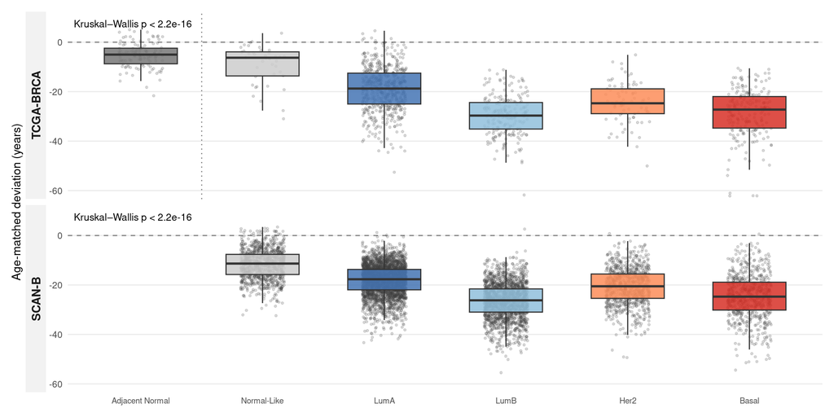

```r
# Palette (matches Panel C, with NAT anchor color from survival figure)
pam50_pal <- c(
  "Adjacent Normal" = "#777777",
  "Normal-Like"     = "#cccccc",
  "LumA"            = "#4575b4",
  "LumB"            = "#91bfdb",
  "Her2"            = "#fc8d59",
  "Basal"           = "#d73027"
)

# NAT separator: vertical dotted line between Adjacent Normal (x=1) and the
# tumor subtypes (x=2 onward). Lives only in the TCGA-BRCA facet.
nat_sep_df <- tibble(
  cohort = factor("TCGA-BRCA", levels = c("TCGA-BRCA", "SCAN-B")),
  x      = 1.5
)

# Position p-value labels at top of shared y-axis
y_max <- max(panelD_df$deviation, na.rm = TRUE)
y_min <- min(panelD_df$deviation, na.rm = TRUE)
y_label_pos <- y_max + 0.05 * (y_max - y_min)

panelD_pvals <- panelD_pvals %>%
  mutate(
    deviation = y_label_pos,
    group     = factor("Normal-Like", levels = pam50_levels)
  )


p_panelD <- ggplot(panelD_df, aes(x = group, y = deviation, fill = group)) +
  geom_hline(yintercept = 0, linetype = "dashed", colour = "grey50") +
  geom_vline(
    data        = nat_sep_df,
    aes(xintercept = x),
    linetype    = "dotted",
    colour      = "grey50",
    inherit.aes = FALSE
  ) +
  geom_jitter(width = 0.18, alpha = 0.18, size = 0.7, colour = "grey25") +
  geom_boxplot(width = 0.6, outlier.shape = NA, alpha = 0.85) +
  scale_fill_manual(values = pam50_pal, guide = "none") +
  facet_grid(
    rows   = vars(cohort),
    scales = "free_x",
    space  = "free_x",
    switch = "y"
  ) +
  coord_cartesian(ylim = c(-60, NA)) +
  geom_text(
    data        = panelD_pvals,
    aes(x = -Inf, y = deviation, label = p_label),
    hjust       = -0.05,
    vjust       = 1,
    size        = 3,
    inherit.aes = FALSE
  ) +
  labs(
    x = NULL,
    y = "Age-matched deviation (years)"
  ) +
  theme_minimal(base_size = 10) +
  theme(
    panel.grid.minor   = element_blank(),
    panel.grid.major.x = element_blank(),
    strip.text         = element_text(size = 10, face = "bold"),
    strip.background   = element_rect(fill = "grey95", colour = NA),
    strip.placement    = "outside",
    axis.title.y       = element_text(size = 10),
    axis.text.x        = element_text(size = 7),
    axis.text.y        = element_text(size = 8),
    plot.margin        = margin(10, 10, 10, 10)
  )

p_panelD
```

```r
if (isTRUE(params$save_figures)) {
  ggsave(
    filename = file.path(out_dir, "PanelD_PAM50_deviation.pdf"),
    plot     = p_panelD,
    width    = 4,
    height   = 3.75,
    units    = "in"
  )
  message("Saved: ", file.path(out_dir, "PanelD_PAM50_deviation.pdf"))
}
```

# Panel E — TP53 mutation class and P53 Pathway φ

**TP53 classes (three categories):**

- **WT** — no TP53 mutation
- **Missense** — single amino acid substitution; functionally heterogeneous (some retain activity, some lose it, some change it)
- **Truncating** — nonsense, frameshift, or splice site; produces a prematurely terminated protein, an unambiguous loss of function

The cleanest functional contrast is **Truncating vs WT**, with Missense included as a “mutated but not clearly LOF” comparison group.

**Modeling strategy** (per the `emmeans` interactions vignette [vignette link](https://cran.r-project.org/web/packages/emmeans/vignettes/interactions.html)):

The interaction test confirms whether the two models are statistically distinguishable. If non-significant (and it is, here), pooling is valid and the additive model is the cleaner inferential summary; pairwise contrasts (each TP53 class vs WT) come out via `pairs()` with Dunnett adjustment.

## E.1 — TP53 mutation classifier

Unified classifier that handles both TCGA-BRCA (cBioPortal MAF, `Mutation Type` field) and SCAN-B (Brueffer 2020, `SnpEff.Effect.Class` field) by their mutation-type label. When a sample has multiple TP53 mutations, the highest-impact class wins (Truncating > Missense).

```r
suppressPackageStartupMessages({
  library(emmeans)
  library(broom)
  library(ggpubr)        # stat_pvalue_manual
})

classify_mutation <- function(mutation_type) {
  trunc_classes <- c(
    "Nonsense_Mutation","Frame_Shift_Del","Frame_Shift_Ins","Splice_Site",  # MAF
    "Nonsense","Frameshift","Splicing"                                       # SnpEff
  )
  miss_classes <- c("Missense_Mutation","Missense")
  if (is.na(mutation_type)) return(NA_character_)
  if (mutation_type %in% trunc_classes) return("Truncating")
  if (mutation_type %in% miss_classes)  return("Missense")
  "Other_Mut"   # in-frame indels, splice region, etc. — dropped from analysis
}

aggregate_sample_class <- function(per_mut_classes) {
  per_mut_classes <- per_mut_classes[!is.na(per_mut_classes)]
  if (length(per_mut_classes) == 0)         return(NA_character_)
  if (any(per_mut_classes == "Truncating")) return("Truncating")
  if (any(per_mut_classes == "Missense"))   return("Missense")
  if (any(per_mut_classes == "Other_Mut"))  return("Other_Mut")
  NA_character_
}
```

## E.2 — Classify TCGA-BRCA (cBioPortal MAF)

Reads the cBioPortal TP53 mutation table, classifies each mutation, aggregates per patient barcode (12-char). The TCGA pipeline indexes samples by UUID, so we bridge cBioPortal patient barcodes → pipeline UUIDs via `metadata$tcga.tcga_barcode`. Samples not in the mutation table are coded WT.

```r
tcga_tp53_tsv <- "/restricted/projectnb/agedisease/projects/pancancer_aging_pbock/manuscript_analyses/data/metadata/cBioPortal_TP53-BRCA_table.tsv"
stopifnot(file.exists(tcga_tp53_tsv))

tcga_tp53 <- readr::read_tsv(tcga_tp53_tsv, show_col_types = FALSE)

# Per-sample class from cBioPortal table
tcga_class_per_sample <- tcga_tp53 %>%
  dplyr::filter(Gene == "TP53") %>%
  dplyr::transmute(
    barcode12 = substr(`Sample ID`, 1, 12),
    mut_type  = `Mutation Type`
  ) %>%
  dplyr::rowwise() %>%
  dplyr::mutate(per_mut_class = classify_mutation(mut_type)) %>%
  dplyr::ungroup() %>%
  dplyr::group_by(barcode12) %>%
  dplyr::summarise(class = aggregate_sample_class(per_mut_class), .groups = "drop")

# Bridge: pipeline UUIDs → patient barcode-12
brca_ids <- rownames(cs_brca$phi)
stopifnot("tcga.tcga_barcode" %in% colnames(metadata))

uuid2bar12    <- setNames(substr(metadata[brca_ids, "tcga.tcga_barcode"], 1, 12), brca_ids)
uuid2bar12    <- uuid2bar12[!is.na(uuid2bar12) & uuid2bar12 != ""]
bar12_to_uuid <- setNames(names(uuid2bar12), uuid2bar12)

# Default to WT, overwrite mutated samples
tp53_class_tcga <- rep("WT", length(brca_ids))
names(tp53_class_tcga) <- brca_ids
uuid_match <- bar12_to_uuid[tcga_class_per_sample$barcode12]
keep_tcga  <- !is.na(uuid_match)
tp53_class_tcga[uuid_match[keep_tcga]] <- tcga_class_per_sample$class[keep_tcga]

cat("TCGA-BRCA TP53 class distribution:\n")
```

```
## TCGA-BRCA TP53 class distribution:
```

```r
print(table(tp53_class_tcga, useNA = "ifany"))
```

```
## tp53_class_tcga
##   Missense  Other_Mut Truncating         WT
##        173          6        119        819
```

```r
cat("Bridge: ", sum(keep_tcga), " / ", nrow(tcga_class_per_sample),
    " mutated barcodes mapped into cohort UUIDs\n", sep = "")
```

```
## Bridge: 298 / 300 mutated barcodes mapped into cohort UUIDs
```

## E.3 — Classify SCAN-B (Brueffer 2020 SnpEff)

Same classifier applied to SCAN-B’s SnpEff effect classes (Nonsense / Frameshift / Splicing → Truncating; Missense → Missense). Samples that appear in the Brueffer 2020 cohort but lack a TP53 entry are coded WT; samples outside the cohort of 3,217 are left NA.

```r
scanb_mut <- readr::read_tsv(params$scanb_tp53_tsv, comment = "##", show_col_types = FALSE)
stopifnot(all(c("SAMPLE","gene.symbol","SnpEff.Effect.Class") %in% colnames(scanb_mut)))

scanb_class_per_sample <- scanb_mut %>%
  dplyr::filter(gene.symbol == "TP53") %>%
  dplyr::transmute(
    sample_match = SAMPLE,
    mut_type     = SnpEff.Effect.Class
  ) %>%
  dplyr::rowwise() %>%
  dplyr::mutate(per_mut_class = classify_mutation(mut_type)) %>%
  dplyr::ungroup() %>%
  dplyr::group_by(sample_match) %>%
  dplyr::summarise(class = aggregate_sample_class(per_mut_class), .groups = "drop")

scanb_ids        <- rownames(cs_scanb$phi)
scanb_ids_match  <- sub("\\.k2\\.a\\.t$", "", scanb_ids)
cohort_ids_scanb <- unique(scanb_mut$SAMPLE)

tp53_class_scanb <- rep(NA_character_, length(scanb_ids))
names(tp53_class_scanb) <- scanb_ids
in_cohort <- scanb_ids_match %in% cohort_ids_scanb
tp53_class_scanb[in_cohort] <- "WT"

match_idx  <- match(scanb_class_per_sample$sample_match, scanb_ids_match)
keep_scanb <- !is.na(match_idx)
tp53_class_scanb[match_idx[keep_scanb]] <- scanb_class_per_sample$class[keep_scanb]

cat("\nSCAN-B TP53 class distribution:\n")
```

```
##
## SCAN-B TP53 class distribution:
```

```r
print(table(tp53_class_scanb, useNA = "ifany"))
```

```
## tp53_class_scanb
##   Missense Truncating         WT       <NA>
##        524        165       1595       5460
```

```r
cat("Match: ", sum(keep_scanb), " / ", nrow(scanb_class_per_sample),
    " mutated samples mapped to cohort\n", sep = "")
```

```
## Match: 689 / 733 mutated samples mapped to cohort
```

## E.4 — Build the analysis tibble with P53 Pathway φ

```r
find_p53_col <- function(phi_mat) {
  cands <- c("P53 Pathway","P53 pathway","P53_Pathway")
  hit <- intersect(cands, colnames(phi_mat))[1]
  if (is.na(hit)) {
    idx <- grep("p53.*pathway", colnames(phi_mat), ignore.case = TRUE)
    stopifnot(length(idx) >= 1)
    hit <- colnames(phi_mat)[idx[1]]
  }
  hit
}
p53_col_b <- find_p53_col(cs_brca$phi)
p53_col_s <- find_p53_col(cs_scanb$phi)

clean_pam <- function(x) {
  x <- as.character(x); x[is.na(x) | x == "" | x == "NC"] <- NA_character_
  dplyr::recode(x, "Normal" = "Normal-Like")
}

driver_df <- bind_rows(
  tibble(
    cohort     = "TCGA-BRCA",
    sample_id  = brca_ids,
    PAM50      = clean_pam(metadata[brca_ids, "Subtype_Selected"]),
    TP53_class = tp53_class_tcga[brca_ids],
    p53_phi    = as.numeric(cs_brca$phi[, p53_col_b])
  ),
  tibble(
    cohort     = "SCAN-B",
    sample_id  = scanb_ids,
    PAM50      = clean_pam(scanb_coldata[scanb_ids, "SSP.PAM50"]),
    TP53_class = tp53_class_scanb[scanb_ids],
    p53_phi    = as.numeric(cs_scanb$phi[, p53_col_s])
  )
) %>%
  filter(
    PAM50 %in% c("Normal-Like","LumA","LumB","Her2","Basal"),           #  tumor subtypes
    TP53_class %in% c("WT","Truncating","Missense"),      # 3-way classification
    is.finite(p53_phi)
  ) %>%
  mutate(
    cohort    = factor(cohort, levels = c("TCGA-BRCA","SCAN-B")),
    PAM50     = factor(PAM50,  levels = c("Normal-Like","LumA","LumB","Her2","Basal")),
    TP53_3way = factor(TP53_class, levels = c("WT","Missense","Truncating"))
  )

cat("\nSample sizes per cohort × PAM50 × TP53 class:\n")
```

```
##
## Sample sizes per cohort × PAM50 × TP53 class:
```

```r
print(
  driver_df %>%
    count(cohort, PAM50, TP53_3way) %>%
    tidyr::pivot_wider(names_from = TP53_3way, values_from = n, values_fill = 0) %>%
    arrange(cohort, PAM50),
  n = Inf
)
```

```
## # A tibble: 10 × 5
##    cohort    PAM50          WT Missense Truncating
##    <fct>     <fct>       <int>    <int>      <int>
##  1 TCGA-BRCA Normal-Like    31        7          2
##  2 TCGA-BRCA LumA          523       32         17
##  3 TCGA-BRCA LumB          157       44         15
##  4 TCGA-BRCA Her2           34       32         14
##  5 TCGA-BRCA Basal          74       58         71
##  6 SCAN-B    Normal-Like   168       47         13
##  7 SCAN-B    LumA          911       96         24
##  8 SCAN-B    LumB          367      113         26
##  9 SCAN-B    Her2          128      136         31
## 10 SCAN-B    Basal          21      132         71
```

## E.5 — Fit models, test interaction, compute emmeans + contrasts

Two models, one purpose each (per the emmeans vignette): additive for the pooled effect, interaction for the cohort-stratified means. The interaction test confirms whether pooling is justified.

```r
# Two models, one purpose each
fit_additive <- lm(p53_phi ~ TP53_3way + cohort + PAM50, data = driver_df)
fit_interact <- lm(p53_phi ~ TP53_3way * cohort + PAM50, data = driver_df)

# Does the TP53 effect actually differ between cohorts?
cat("Cohort × TP53 interaction test:\n")
```

```
## Cohort × TP53 interaction test:
```

```r
print(anova(fit_additive, fit_interact))
```

```
## Analysis of Variance Table
##
## Model 1: p53_phi ~ TP53_3way + cohort + PAM50
## Model 2: p53_phi ~ TP53_3way * cohort + PAM50
##   Res.Df   RSS Df Sum of Sq      F  Pr(>F)
## 1   3387 23051
## 2   3385 23017  2    33.392 2.4554 0.08598 .
## ---
## Signif. codes:  0 '***' 0.001 '**' 0.01 '*' 0.05 '.' 0.1 ' ' 1
```

```r
# Pooled additive-model coefficients — the headline numbers
cat("\nPooled additive model — TP53 coefficients (vs WT, adjusted for cohort + PAM50):\n")
```

```
##
## Pooled additive model — TP53 coefficients (vs WT, adjusted for cohort + PAM50):
```

```r
print(
  broom::tidy(fit_additive, conf.int = TRUE) %>%
    filter(grepl("TP53_3way", term)) %>%
    mutate(across(where(is.numeric), ~round(., 3)))
)
```

```
## # A tibble: 2 × 7
##   term                estimate std.error statistic p.value conf.low conf.high
##   <chr>                  <dbl>     <dbl>     <dbl>   <dbl>    <dbl>     <dbl>
## 1 TP53_3wayMissense     -0.041     0.125    -0.327   0.744   -0.286     0.204
## 2 TP53_3wayTruncating   -0.647     0.181    -3.57    0       -1.00     -0.292
```

```r
# Emmeans: stratified from interaction model, pooled from additive
emm_strat  <- emmeans(fit_interact, ~ TP53_3way | cohort)
emm_pooled <- emmeans(fit_additive, ~ TP53_3way)
```

```r
# Helper: strip emmeans summary attributes that break tibble printing
clean_emm <- function(x) {
  df <- as.data.frame(x)
  for (a in c("mesg","pri.info","estName","clNames","by.vars","famSize")) {
    attr(df, a) <- NULL
  }
  tibble::as_tibble(df)
}

contrasts_strat_df <- clean_emm(summary(
  contrast(emm_strat,  method = "trt.vs.ctrl", ref = "WT", adjust = "dunnettx"),
  infer = TRUE
)) %>% mutate(panel = as.character(cohort))

contrasts_pool_df <- clean_emm(summary(
  contrast(emm_pooled, method = "trt.vs.ctrl", ref = "WT", adjust = "dunnettx"),
  infer = TRUE
)) %>% mutate(panel = "Pooled")

contrasts_df <- bind_rows(contrasts_strat_df, contrasts_pool_df) %>%
  mutate(
    panel     = factor(panel, levels = c("Pooled","TCGA-BRCA","SCAN-B")),
    TP53_3way = sub(" - WT$", "", contrast),
    p_label   = case_when(
      is.na(p.value)  ~ NA_character_,
      p.value < 0.001 ~ "p < 0.001",
      TRUE            ~ paste0("p = ", sprintf("%.3f", p.value))
    )
  )

cat("\nPer-panel contrasts (each TP53 class vs WT, Dunnett-adjusted):\n")
```

```
##
## Per-panel contrasts (each TP53 class vs WT, Dunnett-adjusted):
```

```r
print(
  contrasts_df %>%
    dplyr::select(panel, contrast, estimate, lower.CL, upper.CL, p.value, p_label),
  n = Inf
)
```

```
## # A tibble: 6 × 7
##   panel     contrast        estimate lower.CL upper.CL  p.value p_label
##   <fct>     <chr>              <dbl>    <dbl>    <dbl>    <dbl> <chr>
## 1 TCGA-BRCA Missense - WT    0.00990   -0.490    0.510 0.997    p = 0.997
## 2 TCGA-BRCA Truncating - WT -1.07      -1.67    -0.473 0.000142 p < 0.001
## 3 SCAN-B    Missense - WT   -0.0556    -0.371    0.260 0.881    p = 0.881
## 4 SCAN-B    Truncating - WT -0.359     -0.860    0.141 0.198    p = 0.198
## 5 Pooled    Missense - WT   -0.0409    -0.319    0.237 0.911    p = 0.911
## 6 Pooled    Truncating - WT -0.647     -1.05    -0.244 0.000716 p < 0.001
```

## E.6 — Plot Panel E

Adjusted P53 Pathway φ at each TP53 class × cohort cell, plus the pooled across-cohort estimate. Significance brackets show Dunnett-adjusted contrasts (each TP53 class vs WT).

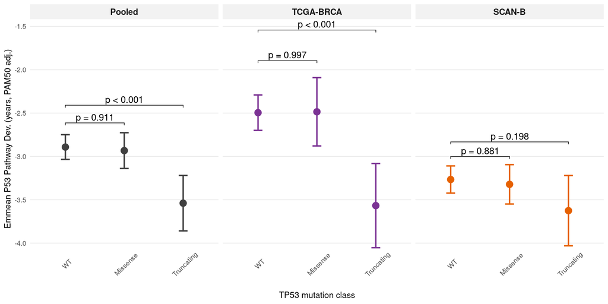

```r
emm_strat_df <- as.data.frame(confint(emm_strat))  %>% mutate(panel = as.character(cohort))
emm_pool_df  <- as.data.frame(confint(emm_pooled)) %>% mutate(panel = "Pooled")

emm_plot_df <- bind_rows(emm_strat_df, emm_pool_df) %>%
  mutate(panel = factor(panel, levels = c("Pooled","TCGA-BRCA","SCAN-B")))

# Color by cohort / pooled panel (replaces the per-class palette)
cohort_pal <- c(
  "Pooled"    = "#404040",   # dark grey = the summary
  "TCGA-BRCA" = "#7b3294",   # purple, matches OS figure
  "SCAN-B"    = "#e66101"    # orange, matches OS figure
)

# Position significance brackets above CI tops, staggered per panel
y_top <- emm_plot_df %>%
  group_by(panel) %>%
  summarise(
    ci_top  = max(upper.CL, na.rm = TRUE),
    ci_span = max(upper.CL, na.rm = TRUE) - min(lower.CL, na.rm = TRUE),
    .groups = "drop"
  )

annot_df <- contrasts_df %>%
  left_join(y_top, by = "panel") %>%
  group_by(panel) %>%
  mutate(
    y.position = ci_top + ci_span * (0.10 + 0.18 * (row_number() - 1)),
    group1 = "WT",
    group2 = TP53_3way
  ) %>%
  ungroup()

p_panelE <- ggplot(emm_plot_df, aes(x = TP53_3way, y = emmean, colour = panel)) +
  geom_errorbar(aes(ymin = lower.CL, ymax = upper.CL),
                width = 0.15, linewidth = 0.8) +
  geom_point(size = 3.5) +
  scale_colour_manual(values = cohort_pal, guide = "none") +
  ggpubr::stat_pvalue_manual(
    annot_df,
    label       = "p_label",
    xmin        = "group1",
    xmax        = "group2",
    y.position  = "y.position",
    tip.length  = 0.01,
    inherit.aes = FALSE
  ) +
  facet_wrap(~ panel, nrow = 1) +
  labs(
    x = "TP53 mutation class",
    y = "Emmean P53 Pathway Dev. (years, PAM50 adj.)"
  ) +
  theme_minimal(base_size = 10) +
  theme(
    strip.text         = element_text(size = 10, face = "bold"),
    strip.background   = element_rect(fill = "grey95", colour = NA),
    panel.grid.minor   = element_blank(),
    panel.grid.major.x = element_blank(),
    axis.text.x        = element_text(size = 8,angle = 45),
    axis.text.y        = element_text(size = 8)
  )

p_panelE
```

```r
if (isTRUE(params$save_figures)) {
  ggsave(
    filename = file.path(out_dir, "PanelE_TP53class_P53phi_EMM.pdf"),
    plot     = p_panelE,
    width    = 3.25,
    height   = 3.75,
    units    = "in"
  )
  message("Saved: ", file.path(out_dir, "PanelE_TP53class_P53phi_EMM.pdf"))
}
```

## Supplementary — Within-PAM50 TP53 truncating effect by cohort

Each row is a cohort × PAM50 cell. The point estimate is the **mean shift in P53 Pathway φ (Truncating − WT, in years)** from a per-cell linear regression `p53_phi ~ TP53_3way`, with the standard t-distribution-based 95% CI. The p-value is the model’s t-test on the Truncating coefficient. Cells with fewer than 10 samples in either group are not tested.

### Per-cell linear models

One linear model per cohort × PAM50 cell, restricted to WT vs Truncating (Missense dropped here for clarity — its absence-of-effect is already established by Panel E). Returns mean shift, 95% CI, and t-test p-value.

```r
run_within_pam50_lm <- function(df, outcome_col = "p53_phi", min_per_group = 10) {
  df %>%
    dplyr::group_by(cohort, PAM50) %>%
    dplyr::group_modify(~ {
      d <- .x %>%
        filter(TP53_3way %in% c("WT", "Truncating")) %>%
        mutate(TP53_3way = droplevels(TP53_3way))
      n_t <- sum(d$TP53_3way == "Truncating")
      n_w <- sum(d$TP53_3way == "WT")
      if (n_t < min_per_group || n_w < min_per_group) {
        return(tibble(
          n_Trunc = n_t, n_WT = n_w,
          est = NA_real_, ci_low = NA_real_, ci_high = NA_real_,
          p_value = NA_real_, skipped = TRUE
        ))
      }
      fit <- lm(reformulate("TP53_3way", outcome_col), data = d)
      ci  <- confint(fit)
      coef_row <- which(grepl("Truncating", rownames(ci)))
      tibble(
        n_Trunc = n_t, n_WT = n_w,
        est     = unname(coef(fit)[coef_row]),
        ci_low  = ci[coef_row, 1],
        ci_high = ci[coef_row, 2],
        p_value = summary(fit)$coefficients[coef_row, "Pr(>|t|)"],
        skipped = FALSE
      )
    }) %>%
    dplyr::ungroup()
}

per_pam50_lm <- run_within_pam50_lm(driver_df) %>%
  mutate(
    PAM50 = factor(PAM50, levels = c("Normal-Like","LumA","LumB","Her2","Basal")),
    p_label = case_when(
      isTRUE(skipped) | is.na(p_value) ~ paste0("n.t. (", n_Trunc, "/", n_WT, ")"),
      p_value < 0.001 ~ paste0("p<0.001 (", n_Trunc, "/", n_WT, ")"),
      TRUE            ~ paste0("p=", sprintf("%.3f", p_value), " (", n_Trunc, "/", n_WT, ")")
    ),
    sig_class = case_when(
      isTRUE(skipped) | is.na(p_value) ~ "skipped",
      p_value < 0.05 ~ "sig",
      TRUE           ~ "ns"
    )
  )

cat("Per-PAM50 mean shift (Truncating − WT) on P53 Pathway φ:\n")
```

```
## Per-PAM50 mean shift (Truncating − WT) on P53 Pathway φ:
```

```r
print(
  per_pam50_lm %>%
    dplyr::select(cohort, PAM50, n_Trunc, n_WT, est, ci_low, ci_high, p_value),
  n = Inf
)
```

```
## # A tibble: 10 × 8
##    cohort    PAM50       n_Trunc  n_WT     est ci_low ci_high p_value
##    <fct>     <fct>         <int> <int>   <dbl>  <dbl>   <dbl>   <dbl>
##  1 TCGA-BRCA Normal-Like       2    31 NA      NA     NA      NA
##  2 TCGA-BRCA LumA             17   523 -1.86   -3.60  -0.120   0.0362
##  3 TCGA-BRCA LumB             15   157 -1.77   -3.35  -0.185   0.0288
##  4 TCGA-BRCA Her2             14    34 -0.536  -2.57   1.50    0.599
##  5 TCGA-BRCA Basal            71    74 -0.176  -1.58   1.23    0.804
##  6 SCAN-B    Normal-Like      13   168 -0.0505 -1.07   0.965   0.922
##  7 SCAN-B    LumA             24   911 -0.0732 -0.828  0.681   0.849
##  8 SCAN-B    LumB             26   367 -0.594  -1.45   0.266   0.175
##  9 SCAN-B    Her2             31   128 -0.805  -1.63   0.0145  0.0541
## 10 SCAN-B    Basal            71    21 -1.38   -2.59  -0.162   0.0268
```

### Forest plot

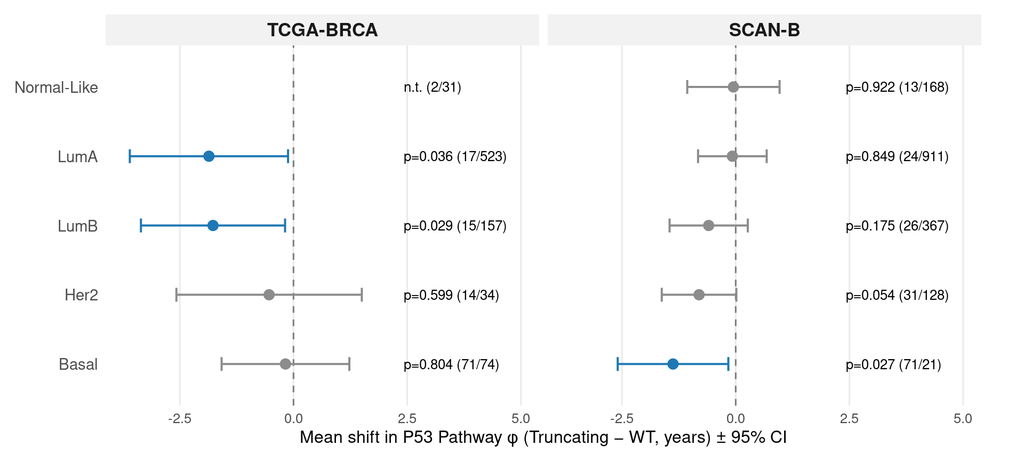

```r
# Global label position so labels align across facets
x_range     <- range(c(per_pam50_lm$ci_low, per_pam50_lm$ci_high), na.rm = TRUE)
x_label_pos <- x_range[2] + 0.18 * diff(x_range)

sig_pal <- c(
  "sig"     = "#1f78b4",
  "ns"      = "grey55",
  "skipped" = "grey85"
)

p_supp_forest <- ggplot(per_pam50_lm, aes(x = est, y = PAM50)) +
  geom_vline(xintercept = 0, linetype = "dashed", colour = "grey50") +
  geom_errorbarh(
    data = filter(per_pam50_lm, !skipped),
    aes(xmin = ci_low, xmax = ci_high, colour = sig_class),
    height = 0.2, linewidth = 0.7
  ) +
  geom_point(aes(colour = sig_class), size = 3) +
  geom_text(
    aes(label = p_label),
    x = x_label_pos, hjust = 0, size = 3.4
  ) +
  scale_colour_manual(values = sig_pal, guide = "none") +
  scale_y_discrete(limits = rev) +    # Basal at top, Normal-Like at bottom
  coord_cartesian(
    xlim = c(x_range[1] - 0.1, x_label_pos + 0.5 * diff(x_range)),
    clip = "off"
  ) +
  facet_wrap(~ cohort, nrow = 1) +
  labs(
    x = "Mean shift in P53 Pathway φ (Truncating − WT, years) ± 95% CI",
    y = NULL
  ) +
  theme_minimal(base_size = 12) +
  theme(
    strip.text         = element_text(size = 13, face = "bold"),
    strip.background   = element_rect(fill = "grey95", colour = NA),
    panel.grid.minor   = element_blank(),
    panel.grid.major.y = element_blank(),
    axis.text.y        = element_text(size = 11),
    plot.margin        = margin(10, 30, 10, 10)
  )

p_supp_forest
```

```r
if (isTRUE(params$save_figures)) {
  ggsave(
    filename = file.path(out_dir, "Supp_TP53_Truncating_byPAM50_forest.pdf"),
    plot     = p_supp_forest,
    width    = 240 / 25.4,
    height   = 110 / 25.4,
    units    = "in"
  )
  message("Saved: ", file.path(out_dir, "Supp_TP53_Truncating_byPAM50_forest.pdf"))
}
```